# 01 - Ajouter des indicateurs

Auteur·rice·s

Yann Say

Laura Grave de Peralta

Gregory Maulet-Toucher

Date de publication

25 mars 2025

# Composition - Ajouter des indicateurs

Le cadre est construit autour de 4 étapes : nettoyage, composition, analyse, résultats.

- **Nettoyage** : toute manipulation nécessaire pour passer des données brutes aux données propres.
- **Composition** : toute manipulation préalable à l’analyse, par exemple l’ajout d’indicateurs, l’ajout d’informations provenant de la boucle ou des données principales, l’agrégation AOK, etc.
- **Analyse** : toute manipulation liée à l’analyse uniquement.
- **Résultats** : toute manipulation nécessaire à la mise en forme des résultats.

La section suivante présentera une introduction à la composition.

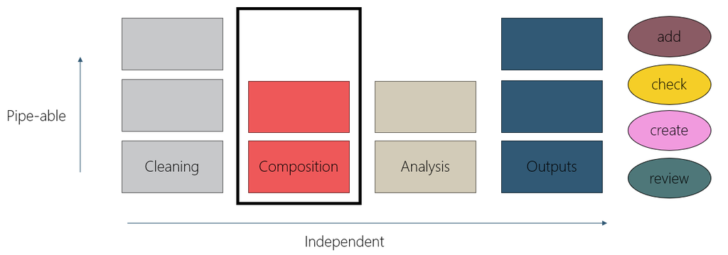

```r
library(impactR4PHU)
library(dplyr)

my_data <- impactR4PHU::impactR4PHU_data_template |>
  filter(respondent_consent != "no")
```

**add_**

les fonctions **add_*** ajouteront une variable (colonne) au jeu de données. Par exemple, pour ajouter la durée d’une enquête, pour ajouter la catégorie de score de consommation alimentaire, etc.

La fonction **add_*** prend un jeu de données en entrée et retourne le jeu de données + le nouvel indicateur (ainsi que toutes les étapes intermédiaires utilisées pour le calcul).

Par exemple, pour vérifier la durée d’une enquête, il n’y a que le début et la fin, mais pas la colonne de durée.

Avec `addindicators`, certaines colonnes intermédiaires peuvent être ajoutées si elles sont utilisées pour créer le nouvel indicateur.

## add_fcs

```r
my_data_with_fcs <- my_data %>% add_fcs(
  cutoffs = "normal"
)

my_data_with_fcs[, tail(names(my_data_with_fcs), 10)] %>%
  head()
```

| fcs_weight_cereal1 | fcs_weight_legume2 | fcs_weight_dairy3 | fcs_weight_meat4 | fcs_weight_veg5 | fcs_weight_fruit6 | fcs_weight_oil7 | fcs_weight_sugar8 | fsl_fcs_score | fsl_fcs_cat |
| --- | --- | --- | --- | --- | --- | --- | --- | --- | --- |
| 6 | 6 | 8 | 8 | 1 | 2 | 0.5 | 1.0 | 32.5 | Borderline |
| 4 | 6 | 4 | 4 | 1 | 2 | 1.0 | 1.0 | 23.0 | Borderline |
| 4 | 3 | 8 | 4 | 1 | 2 | 0.5 | 1.0 | 23.5 | Borderline |
| 4 | 9 | 24 | 16 | 0 | 3 | 3.0 | 3.5 | 62.5 | Acceptable |
| 14 | 3 | 8 | 0 | 0 | 0 | 2.5 | 2.0 | 29.5 | Borderline |
| 4 | 12 | 8 | 0 | 5 | 6 | 2.0 | 3.0 | 40.0 | Acceptable |

**Note**

Vous pouvez en apprendre plus sur les indicateurs de sécurité alimentaire [ici](https://fscluster.org/handbook/).

## add_hhs

**Pipe-able**

Le framework est construit autour de deux adjectifs : **pipe-able** et **independent**. Dans le framework, les fonctions de la même famille sont en principe pipe-able. Dans le cas suivant, deux fonctions **add_*** sont pipées.

```r
my_data_with_indicators <- my_data %>%
  add_fcs(
  cutoffs = "normal"
) %>%
  add_hhs(
  )

my_data_with_indicators[, tail(names(my_data_with_indicators), 14)] %>%
  head()
```

| fsl_fcs_score | fsl_fcs_cat | fsl_hhs_nofoodhh_recoded | fsl_hhs_nofoodhh_freq_recoded | fsl_hhs_sleephungry_recoded | fsl_hhs_sleephungry_freq_recoded | fsl_hhs_alldaynight_recoded | fsl_hhs_alldaynight_freq_recoded | fsl_hhs_comp1 | fsl_hhs_comp2 | fsl_hhs_comp3 | fsl_hhs_score | fsl_hhs_cat_ipc | fsl_hhs_cat |
| --- | --- | --- | --- | --- | --- | --- | --- | --- | --- | --- | --- | --- | --- |
| 32.5 | Borderline | 0 | 0 | 0 | 0 | 0 | 0 | 0 | 0 | 0 | 0 | None | Little to No |
| 23.0 | Borderline | 0 | 0 | 0 | 0 | 0 | 0 | 0 | 0 | 0 | 0 | None | Little to No |
| 23.5 | Borderline | 0 | 0 | 0 | 0 | 0 | 0 | 0 | 0 | 0 | 0 | None | Little to No |
| 62.5 | Acceptable | 0 | 0 | 0 | 0 | 0 | 0 | 0 | 0 | 0 | 0 | None | Little to No |
| 29.5 | Borderline | 0 | 0 | 0 | 0 | 0 | 0 | 0 | 0 | 0 | 0 | None | Little to No |
| 40.0 | Acceptable | 0 | 0 | 0 | 0 | 0 | 0 | 0 | 0 | 0 | 0 | None | Little to No |